# 吸烟与成年人高血压患病的关联性研究——基于NHANES的横断面研究

潘弈彤

2026-07-03

# 1. 研究背景

高血压是心血管疾病的主要危险因素，在全球范围内具有较高的患病率。吸烟作为可改变的心血管危险因素，可通过激活交感神经系统、损伤血管内皮功能升高血压。然而，不同人群、不同数据来源中吸烟与高血压的关联强度存在一定差异，二者的独立关联仍有待在全国代表性样本中进一步验证。美国国家健康与营养调查（NHANES）具有良好的人群代表性，适合开展慢性病危险因素关联研究。

# 2. 研究问题

本研究依托 NHANES 2017–2018 年横断面数据，在校正潜在混杂因素并开展敏感性分析验证结果稳健性后，吸烟与成年人高血压患病是否存在独立关联，明确吸烟是否为高血压患病的独立危险因素。

# 3. 数据来源与研究对象

## 3.1 数据来源

本研究数据来源于美国国家健康与营养调查（National Health and Nutrition Examination Survey, NHANES）2017-2018 年周期数据。NHANES是一项具有全国性 的横断面调查，采用复杂、多阶段概率抽样设计，评估美国平民、非机构化人群的健康和营养状况。

## 3.2 纳入排除标准

**纳入标准**： 1. 年龄 ≥ 20 岁 2. 吸烟状态信息完整 3. 高血压状态明确 4.BMI 完整（BMXBMI 非缺失） 5. 教育水平信息完整 **排除标准**： 1. 年龄 <20 岁 2. 吸烟状态缺失 3. 高血压状态缺失或回答”不知道” 4. BMI 缺失 5. 教育水平信息缺失

## 3.3 分析样本

```r
# 样本量
# 仅读取提前导出的样本汇总结果，不做任何数据计算
n_total <- sample_summary$n_total
n_htn <- sample_summary$n_htn
n_non_htn <- sample_summary$n_non_htn
n_smoking <- sample_summary$n_smoking
```

# 4. 变量定义

## 4.1 高血压（结局变量）

高血压定义为满足以下任一条件： 1. 平均收缩压 ≥ 140 mmHg 或 平均舒张压 ≥ 90 mmHg 2. 曾被医生诊断高血压（BPQ020 = 1）

其中，平均收缩压和舒张压为三次测量值的平均值。

## 4.2 吸烟状态（暴露变量）

吸烟状态分为三组： - **Never**：一生吸烟 < 100 支（SMQ020 = 2） - **Former**：吸过 ≥ 100 支，现在不吸（SMQ020 = 1 且 SMQ040 = 3） - **Current**：吸过 ≥ 100 支，现在每天或偶尔吸（SMQ020 = 1 且 SMQ040 ∈{1,2}）

## 4.3 协变量

本研究考虑的潜在协变量包括：年龄（≤ 60，> 60）、性别（Male/Female）、种族（6类）、BMI分组（WHO标准四分类）、教育水平（三分类）、 家庭收入与贫困比PIR（三分类）。

# 5. 统计方法

## 5.1 数据预处理

本研究导入 NHANES 2017–2018 周期原始合并数据集后，首先对全部变量进行初步探查，核对变量标签、编码定义与缺失值分布。随后严格按照预设的纳入与排除标准筛选研究对象：纳入年龄≥20 岁、高血压结局、吸烟暴露状态、BMI指标完整的研究个体；排除年龄小于20岁、吸烟状态信息缺失或回答“未知”、血压测量数据缺失、BMI 指标缺失、教育水平信息缺失的观测，对PIR的缺失值采用多重插补方法进行填补。剔除暴露、结局与核心协变量存在缺失的样本，最终生成清洗完成的分析数据集。 完成样本筛选后，对关键研究变量进行预处理：高血压结局、吸烟暴露保留原始分类编码；将连续型变量年龄、体质量指数BMI、家庭收入与贫困比PIR，通过参考相关文献，依据国内外流行病学研究通用界值进行分组，转换为分类变量；种族分类、教育水平直接沿用NHANES数据库原有分层。所有分析变量完成编码重构后，导出保存用于后续全部加权统计分析。

## 5.2 统计分析

本研究所有分析均考虑 NHANES 复杂抽样设计，使用 MEC 检查权重（WTMEC2YR）进行加权分析。 采用描述性分析和卡方检验分析基线特征，绘制不同吸烟状态高血压患病率条形图，森林图。 采用加权 logistic 回归模型评估吸烟与高血压的关联，构建两个模型： - **模型一（粗模型）**：仅纳入吸烟状态 - **模型二（全调整模型）**：纳入吸烟状态 + 年龄 + 性别 + 种族 + BMI

## 5.3 补充分析

按照年龄、性别进行分层分析，探索关联的异质性。在模型2的基础上分别纳入教育水平和PIR构建模型，进行敏感性分析，观察吸烟与高血压关联的效应值及其95%置信区间的变化，以验证结果的稳健性。

## 5.4 统计指标与软件

效应指标为比值比（OR）及其 95% 置信区间（CI）。所有分析使用 R 4.6.0 完成。

# 6. 结果

## 6.1 研究对象基线特征

**表1 按高血压分组的人群基线特征（加权分析）**

```r
# 直接插入预格式化表格
desc_formatted_table
```

```
## # A tibble: 23 × 5
##    variable  category           `0`               `1`              P值
##    <chr>     <fct>              <chr>             <chr>            <chr>
##  1 smoking   Current            25811207 (18.2%)  15382949 (16.4%) ""
##  2 smoking   Former             28436784 (20.1%)  29728708 (31.7%) "<0.001"
##  3 smoking   Never              87427244 (61.7%)  48525342 (51.8%) ""
##  4 age_group >60                20290777 (14.3%)  43339988 (46.3%) "<0.001"
##  5 age_group ≤60                121384458 (85.7%) 50297010 (53.7%) ""
##  6 gender    Female             76700359 (54.1%)  45426741 (48.5%) "0.009"
##  7 gender    Male               64974875 (45.9%)  48210258 (51.5%) ""
##  8 race      Mexican American   15191864 (10.7%)  5348632 (5.7%)   ""
##  9 race      Non-Hispanic Asian 9080592 (6.4%)    4771061 (5.1%)   ""
## 10 race      Non-Hispanic Black 13907643 (9.8%)   12894317 (13.8%) "<0.001"
## # ℹ 13 more rows
```

## 6.2 吸烟与高血压的关联分析

### 6.2.1 不同吸烟状态的高血压患病情况比较

**表2 不同吸烟状态的高血压患病情况**

```r
smoking_htn_table_formatted
```

```
##   吸烟状态    总人数        非高血压          高血压     χ2    p值
## 1  Current  41194155 25811207 (62.7) 15382949 (37.3) 22.904 <0.001
## 2   Former  58165492 28436784 (48.9) 29728708 (51.1)
## 3    Never 135952585 87427244 (64.3) 48525342 (35.7)
```

加权卡方检验显示，不同吸烟状态人群的高血压患病率存在显著差异（χ² = 22.904，P < 0.001）。从不吸烟者（Never）：加权患病率为35.7%；曾经吸烟者（For mer）：加权患病率为 51.1%；当前吸烟者（Current）：加权患病率为 37.3%。 其中，曾经吸烟者（Former）的高血压患病率最高（51.1%），远高于从不吸烟者（35.7%）和当前吸烟者（37.3%）。从不吸烟者和当前吸烟者的患病率接近（35.7% vs 37.3%）。

### 6.2.2 不同吸烟状态的高血压患病率（条形图）

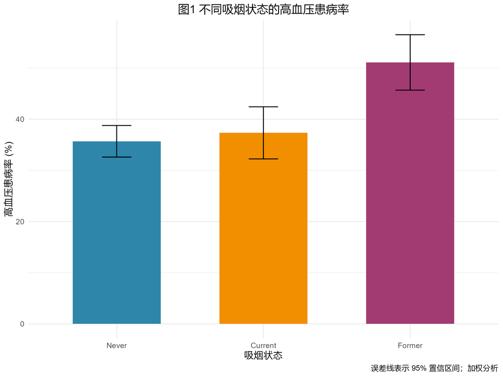

```r
knitr::include_graphics("../figures/figure1_htn_by_smoking.png")
```

图1 直观展示了不同吸烟状态的高血压加权患病率及其95%置信区间。从图中可见，曾经吸烟者（Former）的高血压患病率最高（51.1%），显著高于从不吸烟者（35.7%）和当前吸烟者（37.3%）；当前吸烟者的患病率（37.3%）略高于从不吸烟者（35.7%），但差距较小，且置信区间存在重叠，提示这一差异在统计上可能不显著。 值得注意的是，当前吸烟者与从不吸烟者的患病率差异并不明显，这一现象可能受“健康吸烟者效应”影响——长期吸烟者中体质较弱者可能已经死亡，存活者相对健康；同时，戒烟者往往因健康问题而就医，导致其高血压检出率更高（51.1%）。此外，年龄、性别、BMI等混杂因素也可能影响这一粗关联，需在后续多因素回归中进一步调整后明确吸烟的独立效应。

### 6.2.3 多因素 logistic 回归（主分析）

**表3 吸烟与高血压关联的加权 logistic 回归分析**

```r
main_reg_formatted_table
```

```
##               变量 粗模型_OR    粗模型_95CI 粗模型_P 调整模型_OR  调整模型_95CI
## 1 Current vs Never     1.074 (0.865, 1.333)    0.518       1.286 (1.007, 1.642)
## 2  Former vs Never     1.884 (1.566, 2.265)   <0.001       1.416 (1.184, 1.694)
##   调整模型_P
## 1      0.044
## 2     <0.001
```

基于单因素分析结果，教育水平和 PIR 与高血压的关联均未达到统计学显著性水平，因此未纳入多因素模型。最终模型调整的协变量包括年龄、性别、种族和BMI。 全调整模型（调整年龄、性别、种族、BMI）显示：曾经吸烟者（Former）的高血压风险比从不吸烟者高 42%（OR = 1.416，95% CI: 1.184-1.694，P < 0.001） 当前吸烟者（Current）的高血压风险比从不吸烟者高 29%（OR = 1.286，95% CI: 1.007-1.642，P = 0.044）。 调整混杂因素后，无论曾经吸烟还是当前吸烟，高血压风险均显著高于从不吸烟者，提示吸烟是高血压的独立危险因素。

值得注意的是，调整混杂因素后，当前吸烟者的 OR 值从 1.074（P = 0.518）升高至 1.286（P = 0.044），说明年龄、性别、种族、BMI等混杂因素对当前吸烟者 等混杂因素对当前吸烟者与高血压的关联存在掩盖效应，即未调整时吸烟的真实效应被这些因素掩盖了。此外，全调整模型中曾经吸烟者的 OR 从 1.884 降至 1.416，降幅约 25%，提示部分关联由混杂因素解释，但调整后仍有统计学意义。

### 6.2.4 森林图

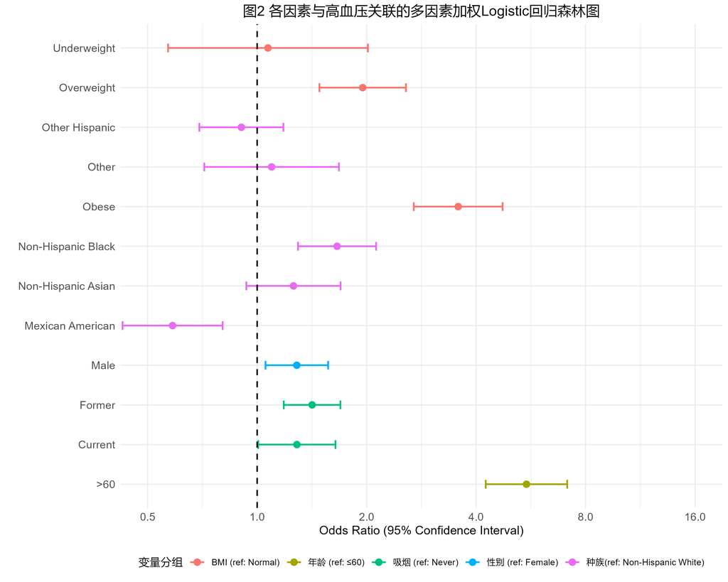

```r
knitr::include_graphics("../figures/figure2_forest_plot.png")
```

图2 以森林图形式展示了全调整模型中各因素与高血压的关联强度及95%置信区间。图中可见，吸烟的OR点估计值大于1，95%CI不与1相交，与主分析结果一致。在纳入模型的所有因素中，年龄 ≥60 岁和肥胖的效应最强（OR > 3），提示二者是高血压最主要的风险因素。

### 6.2.5 模型诊断

为评估模型质量，本研究进行了多重共线性诊断和模型拟合比较。 **多重共线性诊断**：使用方差膨胀因子（VIF）对全调整模型进行共线性诊断，所有变量的GVIF^(1/(2×Df))均小于5（范围：1.46-3.30），提示模型不存在严重的多重共线性问题。 **模型拟合比较**：采用 Rao-Scott 似然比检验比较粗模型与全调整模型的拟合优度。结果显示，全调整模型的拟合显著优于粗模型（LRT χ² = 496.235，df = 10，P < 0.001），提示纳入年龄、性别、种族、BMI 等协变量显著提高了模型的解释力。

## 6.3 敏感性分析

表4 吸烟与高血压关联的敏感性分析

```r
sensitivity_compare_table
```

```
##             变量 主分析_OR      主分析_CI 主分析_P 加PIR_OR       加PIR_CI
## 1  smokingFormer     1.416 (1.184, 1.694)   <0.001    1.410  (1.18, 1.684)
## 2 smokingCurrent     1.286 (1.007, 1.642)    0.044    1.252 (0.981, 1.598)
##   加PIR_P 加教育_OR      加教育_CI 加教育_P
## 1  <0.001     1.397  (1.17, 1.668)   <0.001
## 2   0.071     1.234 (0.975, 1.563)    0.081
```

为验证主分析结果的稳健性，本研究在模型二基础上分别加入PIR和教育水平进行敏感性分析，观察吸烟与高血压关联的OR值变化。结果显示，加入PIR后，曾经吸烟者的 OR 值为 1.410（95% CI: 1.180-1.684，P < 0.001），当前吸烟者的 OR 值为 1.252（95% CI:0.981-1.598，P = 0.071）；加入教育水平后，曾经吸烟者 的 OR 值为 1.397（95% CI: 1.170-1.668，P < 0.001），当前吸烟者的 OR 值为 1.234（95% CI: 0.975-1.563，P = 0.081）。

与主分析相比，无论是否调整 PIR 或教育水平，曾经吸烟者的 OR 值稳定在 1.40 左右，波动幅度很小，且均具有统计学显著性（P < 0.001）；当前吸烟者的 OR 值虽略有下降（从 1.286 降至 1.252 和1.234），95%CI下限略低于1.00，但方向始终一致。整体来看，吸烟与高血压的正向关联在不同模型设定下保持稳定，主结果受 PIR 和教育水平调整的影响较小，具有较好的稳健性。

## 6.4 分层分析

表5 吸烟与高血压关联的分层分析

```r
strat_formatted_table
```

```
##   分层变量   亚组 Former_OR      Former_CI Former_P Current_OR     Current_CI
## 1     性别   Male     1.489     (1.108, 2)    0.058      1.427 (1.073, 1.898)
## 2          Female     1.432  (1.063, 1.93)    0.077      1.208 (0.869, 1.678)
## 3     年龄    ≤60     1.436 (1.083, 1.905)    0.066      1.466 (1.118, 1.923)
## 4             >60     1.398 (0.994, 1.965)    0.126      0.704 (0.479, 1.035)
##   Current_P 交互_P
## 1     0.071  0.596
## 2     0.323
## 3     0.050  0.266
## 4     0.149
```

在敏感性分析的基础上，为进一步探索吸烟与高血压的关联在不同人群中是否一致，本研究按性别和年龄进行分层分析，结果见表5。

按性别分层：男性中吸烟与高血压的关联OR值为1.489（95% CI:1.108-2.000，P = 0.058），女性中OR值为1.432（95% CI:1.063-1.930，P = 0.077），均呈正向 关联。性别与吸烟的交互作用P值为0.596，远大于0.05，说明吸烟与高血压的关联在男性和女性之间无显著差异。

按年龄分层：≤ 60岁组吸烟与高血压的关联OR值为1.436（95% CI: 1.083-1.905，P = 0.066），> 60岁组OR值为1.398（95% CI: 0.994-1.965，P = 0.126），均 大于1，方向与主分析一致。年龄与吸烟的交互作用P值为0.266，远大于0.05，说明吸烟与高血压的关联在不同年龄组之间无显著差异。

# 7. 讨论

## 7.1 主要发现

本研究发现，调整年龄、性别、种族、BMI 等混杂因素后，吸烟与高血压之间存在显著的正向关联。曾经吸烟者的高血压风险比从不吸烟者高 42%（OR = 1.416， 95% CI: 1.184-1.694，P < 0.001）；当前吸烟者的高血压风险比从不吸烟者高 29%（OR = 1.286，95% CI: 1.007-1.642，P = 0.044）。分层分析显示该关联在 不同性别和年龄组中无显著差异（交互 P 均 > 0.05），敏感性分析进一步验证了结果的稳健性。

本研究结果与现有文献基本一致。Wu 等（2025）基于 NHANES 1999-2018 数据发现，吸烟显著增加高血压风险（调整后 OR = 1.18，95% CI:1.10-1.27），本研究 的 OR 值与之方向一致但略高，可能与单周期数据带来的样本量差异和人群构成差异有关。Sun和Li（2024）同样发现吸烟与多种健康风险的正向关联，提示吸烟对健康的影响具有多系统性特征。值得注意的是，本研究中曾经吸烟者的效应（OR = 1.416）高于当前吸烟者（OR = 1.286），与Wu等（2025）的结果模式一致，可 能反映的是“戒烟者因健康问题就医，从而增加了高血压被检出的机会”，这一现象在横断面研究中并不少见。

## 7.2 潜在机制与临床意义

吸烟可能通过多种机制升高血压。尼古丁可激活交感神经系统，促进儿茶酚胺释放，导致心率加快和血管收缩；同时可诱导血管内皮功能障碍，损害一氧化氮介导的血管舒张功能，增加外周血管阻力；还可激活全身慢性炎症状态，进一步加速血管损伤和血压升高。这些机制共同解释了吸烟与高血压之间的正向关联，也提示吸烟对心血管系统的损害是多靶点、多通路的。

## 7.3 局限性

1. 横断面研究设计，无法推断因果关系
2. 高血压部分基于自报，可能存在回忆偏倚
3. 仅纳入单周期 NHANES 数据，样本量有限
4. 吸烟状态为自报，可能存在报告偏倚

# 8. 结论